# Psychometric modeling of the Syntactic Complexity Scale of the CDI

Seamus Donnelly

```r
library(wordbankr) # WB data
library(tidyverse) # tidy
library(mirt) # IRT models
library(ltm) # more IRT functions
library(psych) # some psychometric stuff (tests of dimensionality)
library(Gifi)# some more psychometric stuff (tests of dimensionality)
library(knitr) # some formatting, tables, etc
library(patchwork) # combining plots.
library(GGally) # More plottinng options.
library(lordif) # differential item functioning.
```

In our meeting on 01/09/2021, we discussed the possibility that our sample was a mixture of children, grammatical kids and pre-grammatical kids. We said one way to remove the pre-grammatical kids would be to exclude kids who have a 0 on the variable indicating whether children combine words, and on any of the morphological variables. One concern is whether kids who are not combining words but are using ing, ed or s. It’s not clear whether these kids are pre-grammatical or not.

Download data from Word Bank:

```r
Inst <- get_instrument_data(language="English (American)", form="WS")
Admin <- get_administration_data(language="English (American)", form="WS")
Item <- get_item_data(language="English (American)", form = "WS")
```

```r
Complex <- Admin %>%
  full_join(.,Inst, by="data_id") %>%
  full_join(., Item, by="num_item_id") %>%
  filter(longitudinal==FALSE) %>%
  filter(type == "combine" |
           type == "complexity" |
           type == "word_endings" |
           type== "word_forms_nouns" |
           type == "word_forms_verbs" |
           type == "word_endings_nouns" |
           type == "word_endings_verbs"
         ) %>%
  mutate(
    out = ifelse(value=="complex" | value=="sometimes" | value=="produces", yes=1,
                 no = ifelse(value=="often", yes=2, no =0))
  )
```

As a quick sanity check, let’s see which items have ordinal data (to make sure the above code worked correctly).

```r
Complex %>%
  filter(out==2) %>%
  group_by(definition) %>%
  count()
```

| definition | n |
| --- | --- |
| ed | 155 |
| has your child begun to combine word yet? | 1390 |
| ing | 403 |
| splural | 797 |
| spossess | 1048 |

Ok, it’s only the combine variable and word endings variables – that’s right.

## 0.1 Data Screening

Let’s see how many missing values there are.

```r
Complex %>%
  filter(is.na(out)) %>%
  group_by(definition) %>%
  count()
```

| definition | n |
| --- | --- |
| ate | 1428 |
| ated | 1427 |
| baby blanket / baby's blanket | 1426 |
| baby crying / baby crying cuz she's sad | 1426 |
| baby crying / baby is crying | 1426 |
| baby want eat / baby want to eat | 1426 |
| blew | 1428 |
| blewed | 1427 |
| blockses | 1427 |
| blowed | 1427 |

[output cut: 102 more lines]

Looks like there are 1426 participants don’t have item-level complexity scores. There are a further 2 who don’t have word forms, and 1 who doesn’t have word endings.

```r
Complex$complexity_category <- ifelse(Complex$complexity_category == "", yes=Complex$type, no=Complex$complexity_category)
```

```r
Complex %>%
  filter(!is.na(out)) %>%
  group_by(definition) %>%
  summarise(
    mean=mean(out),
    sd=sd(out),
    sum=sum(out),
    category = first(complexity_category)
  ) %>%
  arrange(category) %>%
  kable(caption="Means and SDs for Each Item (Arranged by Item)")
```

Means and SDs for Each Item (Arranged by Item)

| definition | mean | sd | sum | category |
| --- | --- | --- | --- | --- |
| has your child begun to combine word yet? | 1.2833572 | 0.7960586 | 3578 | combine |
| baby blanket / baby’s blanket | 0.3873745 | 0.4872378 | 1080 | morphology |
| daddy car / daddy’s car | 0.4451220 | 0.4970684 | 1241 | morphology |
| daddy pick me up / daddy picked me up | 0.1743185 | 0.3794512 | 486 | morphology |
| doggie kiss me / doggie kissed me | 0.1879484 | 0.3907410 | 524 | morphology |
| I fall down / I fell down | 0.1807747 | 0.3849005 | 504 | morphology |
| I make tower / I making tower | 0.2360115 | 0.4247055 | 658 | morphology |
| kitty go away / kitty went away | 0.1280488 | 0.3342041 | 357 | morphology |
| kitty sleep / kitty sleeping | 0.4192970 | 0.4935326 | 1169 | morphology |
| more cookie / more cookies | 0.3758967 | 0.4844404 | 1048 | morphology |
| these my tooth / these my teeth | 0.4533716 | 0.4979103 | 1264 | morphology |
| two foot / two feet | 0.4214491 | 0.4938798 | 1175 | morphology |
| two shoe / two shoes | 0.4422525 | 0.4967431 | 1233 | morphology |
| baby crying / baby crying cuz she’s sad | 0.1599713 | 0.3666452 | 446 | syntax |
| baby crying / baby is crying | 0.1624821 | 0.3689586 | 453 | syntax |
| baby want eat / baby want to eat | 0.2650646 | 0.4414468 | 739 | syntax |
| coffee hot / that coffee hot | 0.1929699 | 0.3947004 | 538 | syntax |
| cookie mommy / cookie for mommy | 0.2413917 | 0.4280040 | 673 | syntax |
| doggie table / doggie on table | 0.3511478 | 0.4774147 | 979 | syntax |
| don’t read book / don’t want you read that book | 0.1818508 | 0.3857907 | 507 | syntax |
| go bye-bye / wanna go bye-bye | 0.2679340 | 0.4429625 | 747 | syntax |
| I like read stories / I like to read stories | 0.1779053 | 0.3825016 | 496 | syntax |
| I no do it / I can’t do it | 0.2482066 | 0.4320498 | 692 | syntax |
| I sing song / I sing song for you | 0.1449067 | 0.3520699 | 404 | syntax |
| I want that / I want that one you got | 0.1137016 | 0.3175054 | 317 | syntax |
| lookit / lookit what I got | 0.2410330 | 0.4277870 | 672 | syntax |
| lookit me / lookit me dancing | 0.2596844 | 0.4385400 | 724 | syntax |
| no wash dolly / don’t wash dolly | 0.2116212 | 0.4085310 | 590 | syntax |
| read me story Mommy / read me a story Mommy | 0.1635581 | 0.3699405 | 456 | syntax |
| that my truck / that’s my truck | 0.2822812 | 0.4501902 | 787 | syntax |

[output cut: 82 more lines]

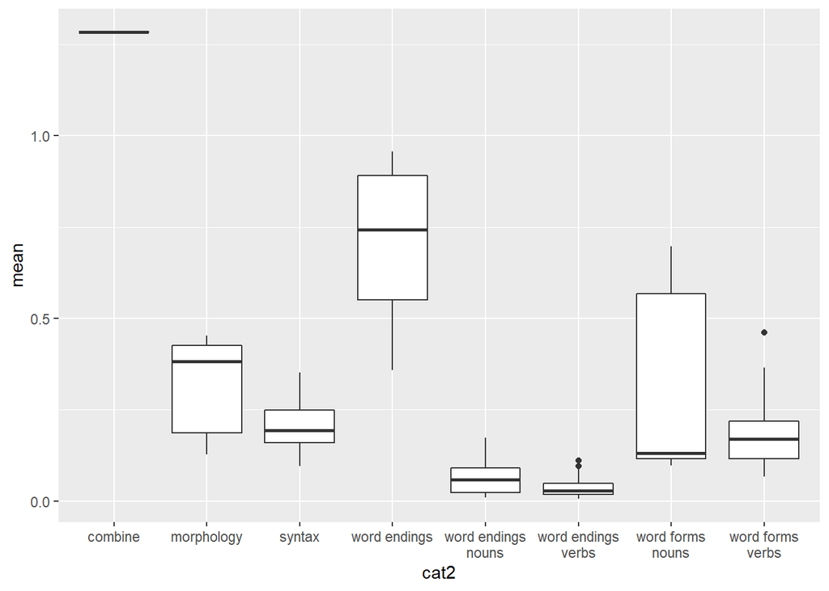

```r
Complex %>%
  filter(!is.na(out)) %>%
  group_by(definition) %>%
  summarise(
    mean=mean(out),
    category = first(complexity_category),
    cat2 = str_replace(category, "_", " " ) %>% str_replace("_", "\n" )
  ) %>%
  ggplot(aes(x=cat2, y= mean)) + geom_boxplot()
```

It seems like the word endings and the combine words variable have higher means than the morphological and syntactic complexity items (though they are ordinal, but when I treated these as binary in an older version the results were the same). The over-regularization items have very low means, and the word forms looks a bit like the syntactic and morphological complexity.

One difficulty I just thought of is that the we would expect the word form and over-regularizations to be non-monotonially related to overall grammatical proficiency, given the inverse u shaped curve we typically see in the development of morphology.

Therefore, I’m going to first add the combine item and the word endings variables, see how that changes the results of the IRT model, and then plot the over-regularization and word form scores against this, to see if we see the non-monotonicity.

## 0.2 Data Preparation

Prepare data set for IRT modeling. I’m going to re-name each item to its category (morphology or syntax) and its item number so as to make some graphs easier to read.

```r
Complex_short_with_ids <- Complex %>%
  dplyr::select(data_id, value, out, complexity_category, num_item_id) %>%
  mutate(
    label = str_c(complexity_category, num_item_id)
  ) %>%
  pivot_wider(id_cols=data_id, names_from = "label", values_from="out") %>%
  drop_na()


Complex_short <- Complex_short_with_ids %>%
  dplyr::select(starts_with(c("combine", "morphology", "syntax")), c("word_endings686", "word_endings687", "word_endings688", "word_endings689")) # dataset for IRT can't have IDs
```

```r
Complex_short %>%
  filter(combine760==0) %>%
  dplyr::select(word_endings686, word_endings687, word_endings688, word_endings689) %>%
  mutate(
    total = word_endings686 + word_endings687 + word_endings688 +   word_endings689,
    morph = ifelse(total == 0, yes = 0, no =1)
  ) %>%
  group_by(morph) %>%
  count()
```

| morph | n |
| --- | --- |
| 0 | 493 |
| 1 | 107 |

So, there are 600 kids with a 0 on combines words. Of those, 107 kids are producing morphological forms. I think it makes sense to be conservative about who’s grammatical and exclude those 107 kids. I’m going to make two datasets for the IRT models: one including all participants and one including those who met our stringent definition of grammatical.

```r
Complex_short_grammatical <- Complex_short %>%
  filter(combine760 > 0) %>%
  dplyr::select(starts_with(c("morphology", "syntax")))

Complex_short_all <- Complex_short %>%
  dplyr::select(starts_with(c("morphology", "syntax")))
```

## 0.3 Dimensionality Assessment

Prior to fitting the IRT model, it’s worth looking at the correlation structure of the data to get a sense of the possible dimensionality.

### 0.3.1 First for grammatical kids only

Create tetrachoric correlation matrix (for binary data). I created a vector with labels, for labeling of the correlation plot.

```r
Complex_tetra <- tetrachoric(Complex_short_grammatical)
```

```r
rho <- Complex_tetra$rho

lab = c("1", "2", "3", "4", "5", "6", "7", "8", "9", "10", "11", "12", "13", "14", "15", "16", "17", "18", "19", "20", "21", "22", "23", "24", "25", "26", "27", "28", "29", "30", "31", "32", "33", "34", "35", "36", "37") # create labels for corPlot because the defintions are long and take up a ton of space
```

Check out the correlations

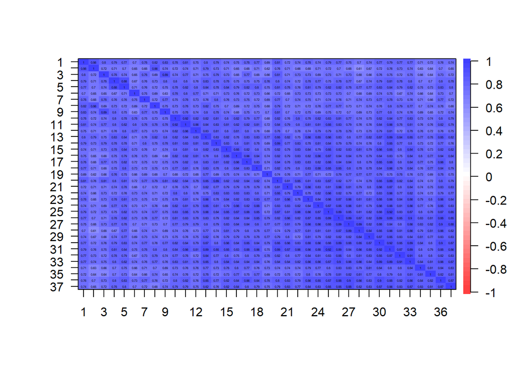

```r
corPlot(rho, labels=lab)
```

They look really high. Let’s examine the dimensionality, using princals, which is basically just a version of PCA that is appropriate for categorical data.

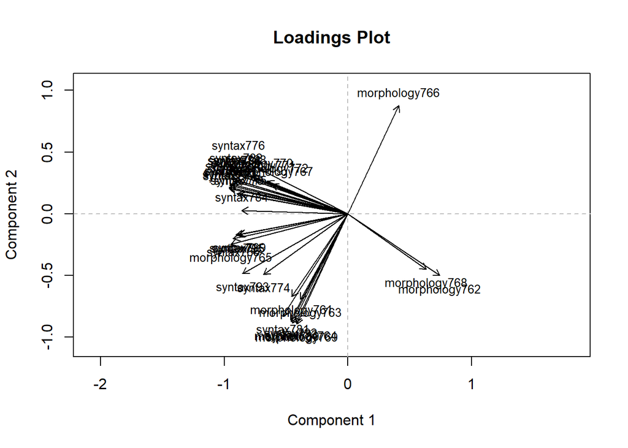

```r
pc <- princals(rho)

plot(pc)
```

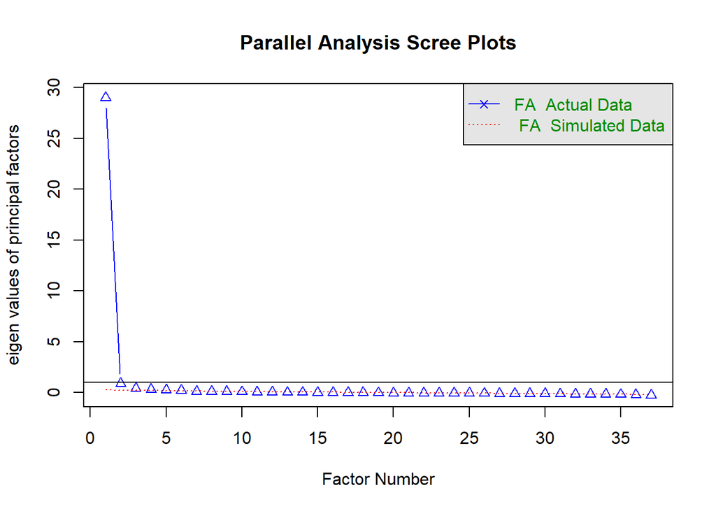

```
## Parallel analysis suggests that the number of factors =  6  and the number of components =  NA
```

```r
fa.parallel(rho, fa="fa", cor="tetra", n.obs = 2185)
```

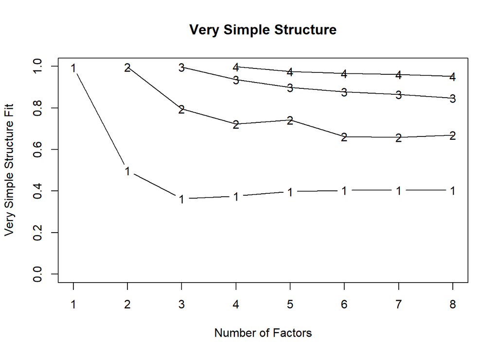

```
##
## Very Simple Structure
## Call: vss(x = rho, n.obs = 2185, cor = "tetra")
## VSS complexity 1 achieves a maximimum of 1  with  1  factors
## VSS complexity 2 achieves a maximimum of 1  with  2  factors
##
## The Velicer MAP achieves a minimum of 0.02  with  4  factors
## BIC achieves a minimum of  10758.74  with  8  factors
## Sample Size adjusted BIC achieves a minimum of  12023.25  with  8  factors
##
## Statistics by number of factors
##   vss1 vss2   map dof chisq prob sqresid fit RMSEA   BIC SABIC complex eChisq
## 1 1.00 0.00 0.024 629 29234    0    3.38   1  0.14 24397 26396     1.0   3228
## 2 0.50 1.00 0.017 593 23749    0    2.18   1  0.13 19189 21073     1.8   1525
## 3 0.36 0.80 0.016 558 21230    0    1.77   1  0.13 16939 18712     2.4   1075
## 4 0.38 0.72 0.016 524 19000    0    1.46   1  0.13 14971 16635     2.8    770
## 5 0.40 0.74 0.016 491 17308    0    1.27   1  0.13 13533 15093     3.1    600
## 6 0.40 0.66 0.017 459 15841    0    1.11   1  0.12 12311 13770     3.2    466
## 7 0.40 0.66 0.019 428 14898    0    1.00   1  0.12 11607 12966     3.3    393
## 8 0.40 0.67 0.020 398 13819    0    0.92   1  0.12 10759 12023     3.4    339
##    SRMR eCRMS  eBIC
## 1 0.033 0.034 -1608
## 2 0.023 0.024 -3035
## 3 0.019 0.021 -3216
## 4 0.016 0.018 -3259
## 5 0.014 0.017 -3176
## 6 0.013 0.015 -3063
## 7 0.012 0.015 -2898
## 8 0.011 0.014 -2721
```

```r
vss(rho, cor="tetra", n.obs = 2185)
```

### 0.3.2 All Kids

```r
Complex_tetra <- tetrachoric(Complex_short_all)
```

```r
rho <- Complex_tetra$rho

lab = c("1", "2", "3", "4", "5", "6", "7", "8", "9", "10", "11", "12", "13", "14", "15", "16", "17", "18", "19", "20", "21", "22", "23", "24", "25", "26", "27", "28", "29", "30", "31", "32", "33", "34", "35", "36", "37") # create labels for corPlot because the defintions are long and take up a ton of space
```

Check out the correlations

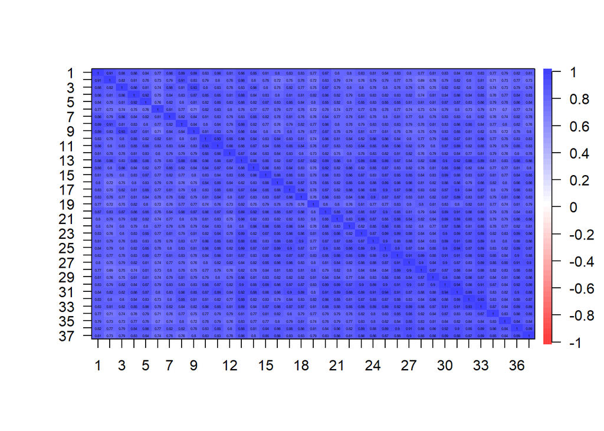

```r
corPlot(rho, labels=lab)
```

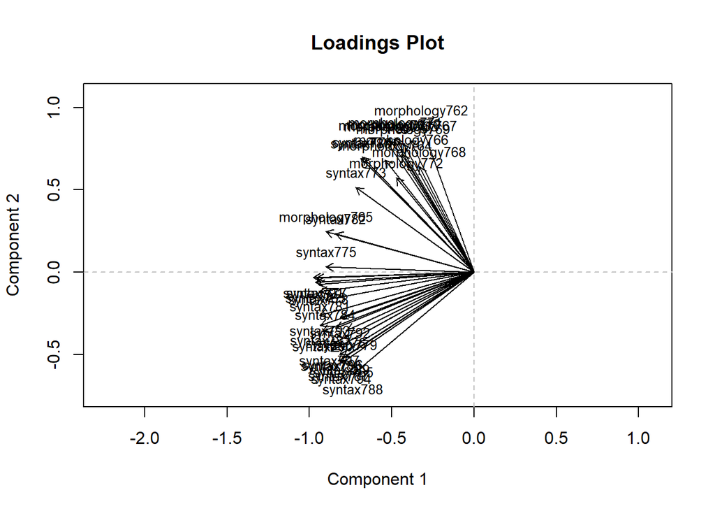

```r
pc <- princals(rho)

plot(pc)
```

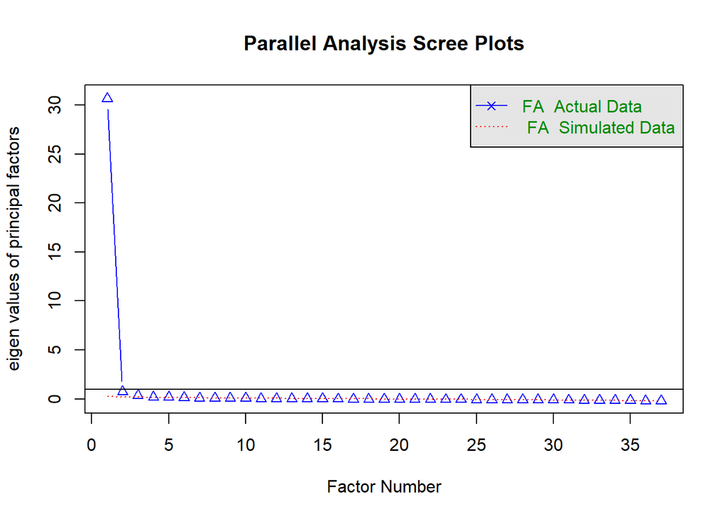

```
## Parallel analysis suggests that the number of factors =  5  and the number of components =  NA
```

```r
fa.parallel(rho, fa="fa", cor="tetra", n.obs = 2785)
```

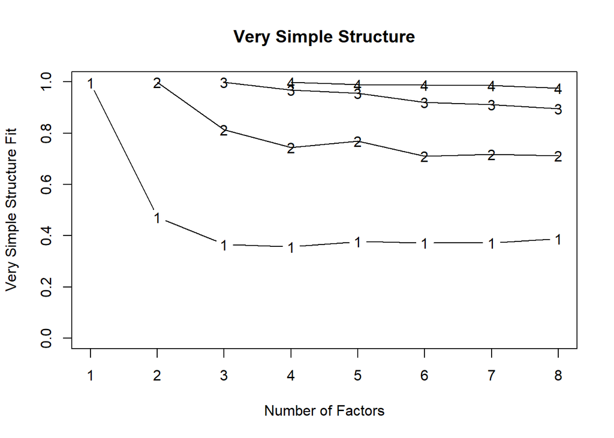

```
##
## Very Simple Structure
## Call: vss(x = rho, n.obs = 2785, cor = "tetra")
## VSS complexity 1 achieves a maximimum of 1  with  1  factors
## VSS complexity 2 achieves a maximimum of 1  with  2  factors
##
## The Velicer MAP achieves a minimum of 0.02  with  4  factors
## BIC achieves a minimum of  17923.79  with  8  factors
## Sample Size adjusted BIC achieves a minimum of  19188.37  with  8  factors
##
## Statistics by number of factors
##   vss1 vss2   map dof chisq prob sqresid fit RMSEA   BIC SABIC complex eChisq
## 1 1.00 0.00 0.026 629 42035    0    2.18   1  0.15 37046 39044     1.0   2778
## 2 0.47 1.00 0.018 593 33909    0    1.36   1  0.14 29205 31089     1.8   1241
## 3 0.37 0.81 0.017 558 30360    0    1.08   1  0.14 25934 27707     2.5    827
## 4 0.36 0.74 0.017 524 27416    0    0.93   1  0.14 23259 24924     2.9    629
## 5 0.38 0.77 0.017 491 25227    0    0.81   1  0.13 21332 22892     3.1    488
## 6 0.37 0.71 0.018 459 23369    0    0.72   1  0.13 19728 21186     3.3    393
## 7 0.37 0.72 0.019 428 22262    0    0.63   1  0.14 18867 20227     3.3    332
## 8 0.39 0.71 0.021 398 21081    0    0.57   1  0.14 17924 19188     3.4    283
##     SRMR eCRMS  eBIC
## 1 0.0274 0.028 -2211
## 2 0.0183 0.019 -3462
## 3 0.0149 0.016 -3599
## 4 0.0130 0.015 -3527
## 5 0.0115 0.013 -3406
## 6 0.0103 0.012 -3248
## 7 0.0095 0.012 -3063
## 8 0.0087 0.011 -2874
```

```r
vss(rho, cor="tetra", n.obs = 2785)
```

It seems like the one factor solution is most plausible for both the full dataset and the dataset with grammatical kids. One obvious difference, though, is that in the princal plot for the grammatical dataset a few items appeared to differ quite differntly from the others. I’m first going to do some IRT with the grammatical-only dataset, and I’m goig to see if those vectors were a quirk of the scaling

# 1 IRT: Grammatical only

## 1.1 2pl model

```r
m1 <- mirt(Complex_short_grammatical, 1, itemtype="2PL")
```

[output not shown]

[output cut: 159 more lines]

[output not shown]

```r
m1
```

```
##
## Call:
## mirt(data = Complex_short_grammatical, model = 1, itemtype = "2PL")
##
## Full-information item factor analysis with 1 factor(s).
## Converged within 1e-04 tolerance after 213 EM iterations.
## mirt version: 1.34
## M-step optimizer: BFGS
## EM acceleration: Ramsay
## Number of rectangular quadrature: 61
## Latent density type: Gaussian
##
## Log-likelihood = -24891.31
## Estimated parameters: 74
## AIC = 49930.62; AICc = 49935.88
## BIC = 50351.63; SABIC = 50116.52
## G2 (1e+10) = 24028.81, p = 1
## RMSEA = 0, CFI = NaN, TLI = NaN
```

```r
summary(m1)
```

```
##                  F1    h2
## morphology761 0.888 0.789
## morphology762 0.838 0.703
## morphology763 0.845 0.714
## morphology764 0.878 0.771
## morphology765 0.909 0.826
## morphology766 0.831 0.690
## morphology767 0.852 0.726
## morphology768 0.866 0.750
## morphology769 0.868 0.754
## morphology770 0.910 0.829
## morphology771 0.930 0.866
## morphology772 0.897 0.805
## syntax773     0.936 0.876
## syntax774     0.908 0.824
## syntax775     0.925 0.856
## syntax776     0.933 0.870
## syntax777     0.933 0.870
## syntax778     0.916 0.839
## syntax779     0.854 0.730
## syntax780     0.930 0.864
## syntax781     0.901 0.812
## syntax782     0.906 0.821
## syntax783     0.937 0.878
## syntax784     0.925 0.856
## syntax785     0.955 0.912
## syntax786     0.952 0.907
## syntax787     0.945 0.892
## syntax788     0.917 0.840
## syntax789     0.910 0.827
## syntax790     0.956 0.914
## syntax791     0.964 0.930
## syntax792     0.922 0.851
## syntax793     0.950 0.903
## syntax794     0.901 0.812
## syntax795     0.877 0.769
## syntax796     0.952 0.907
## syntax797     0.932 0.869
##
## SS loadings:  30.654
## Proportion Var:  0.828
##
## Factor correlations:
##
##    F1
## F1  1
```

Let’s check the overall fit of the model. The chi square statistic here isn’t super meaningful given the sample size.

```r
M2(m1)
```

|  | M2 | df | p | RMSEA | RMSEA_5 | RMSEA_95 | SRMSR | TLI | CFI |
| --- | --- | --- | --- | --- | --- | --- | --- | --- | --- |
| stats | 2938.347 | 629 | 0 | 0.04100086 | 0.03950223 | 0.04249314 | 0.04355032 | 0.9937166 | 0.9940657 |

```r
itemfit(m1)
```

| item | S_X2 | df.S_X2 | RMSEA.S_X2 | p.S_X2 |
| --- | --- | --- | --- | --- |
| morphology761 | 26.59633 | 25 | 0.005407106 | 0.37634695 |
| morphology762 | 40.07329 | 29 | 0.013222486 | 0.08274565 |
| morphology763 | 30.69558 | 28 | 0.006639279 | 0.33076281 |
| morphology764 | 37.26614 | 27 | 0.013194577 | 0.09020601 |
| morphology765 | 24.09022 | 31 | 0.000000000 | 0.80684579 |
| morphology766 | 34.10285 | 34 | 0.001176879 | 0.46279455 |
| morphology767 | 26.86879 | 31 | 0.000000000 | 0.67874837 |
| morphology768 | 26.64738 | 26 | 0.003376506 | 0.42800030 |
| morphology769 | 33.94499 | 29 | 0.008836039 | 0.24127938 |
| morphology770 | 34.00346 | 32 | 0.005354127 | 0.37129704 |

[output cut: 27 more lines]

I’m going to use a p-value of .10 as a cut off, to be conservative about false negatives.

```r
misfit <- itemfit(m1) %>% # Get labels of mis-fitting items.
  filter(p.S_X2 <= .10) %>%
  dplyr::select(item) %>%
  as.vector()

items_good <- dplyr::select(Complex_short_grammatical, -all_of(misfit$item)) # Well fitting items
items_bad <- dplyr::select(Complex_short_grammatical, all_of(misfit$item)) # Poorly fitting items

mod_fit <- mirt(items_good, 1, "2PL", verbose=FALSE) # Calculate factor scores using only the well fitting items.
Theta <- fscores(mod_fit)
```

```r
IG762<- itemGAM(items_bad$morphology762, Theta)
IG764<- itemGAM(items_bad$morphology764, Theta)
IG771<- itemGAM(items_bad$morphology771, Theta)
IG783<- itemGAM(items_bad$syntax783, Theta)
IG792<- itemGAM(items_bad$syntax792, Theta)
```

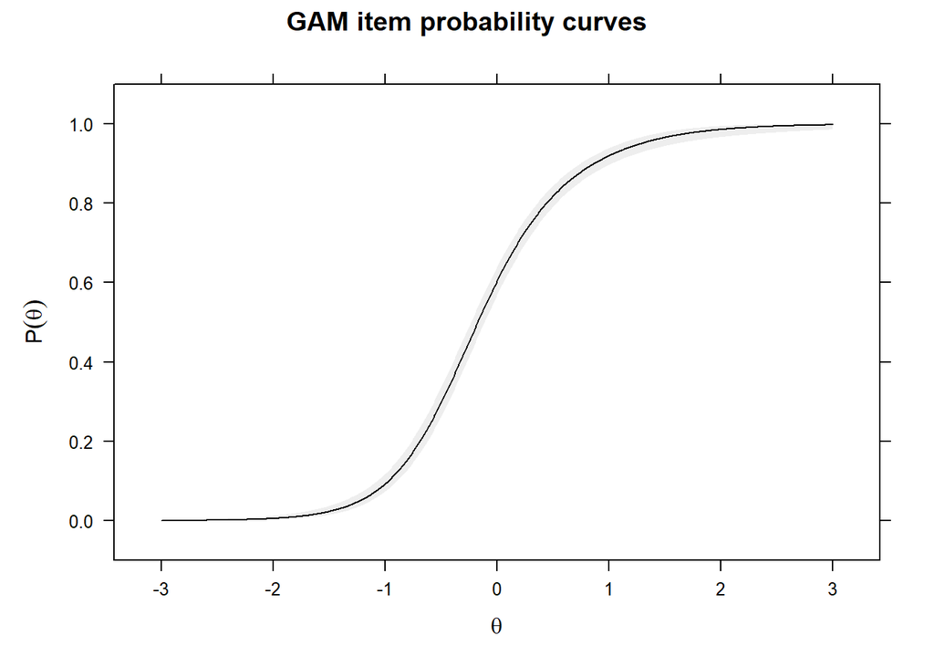

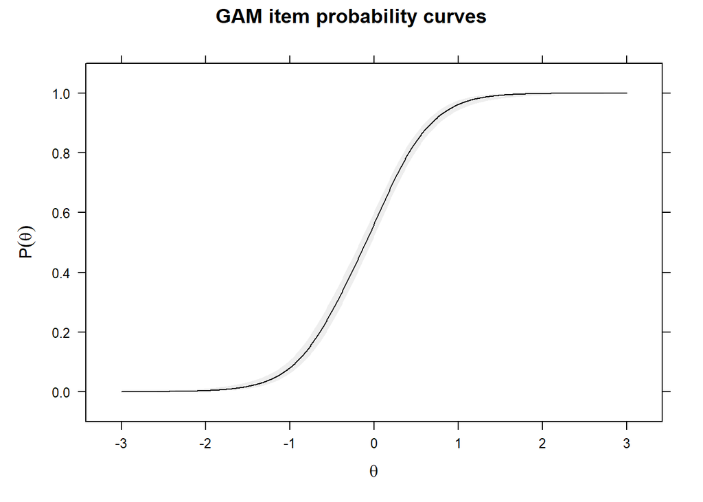

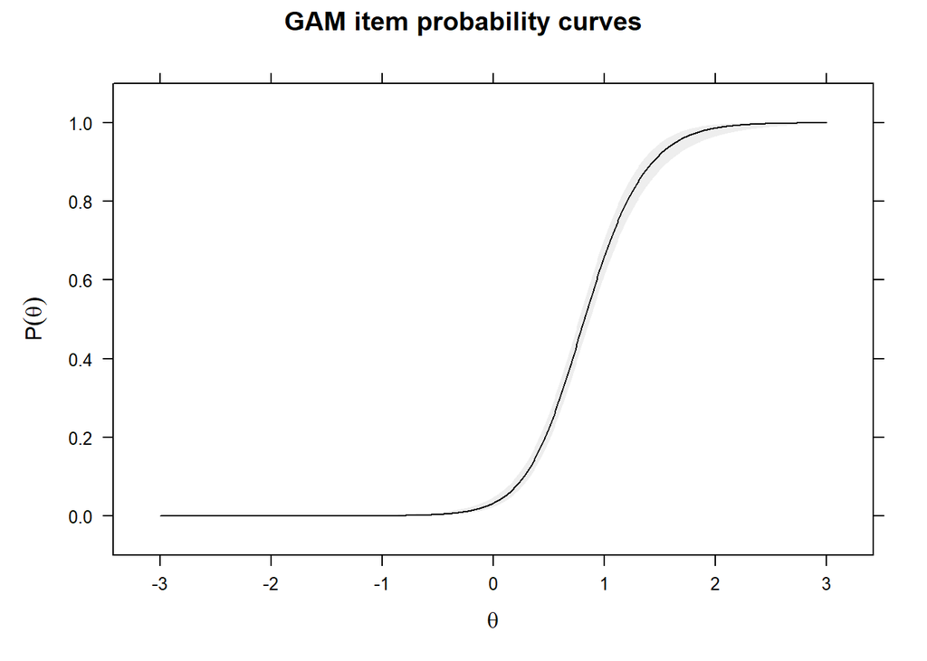

```r
plot(IG762); plot(IG764); plot(IG771)
```

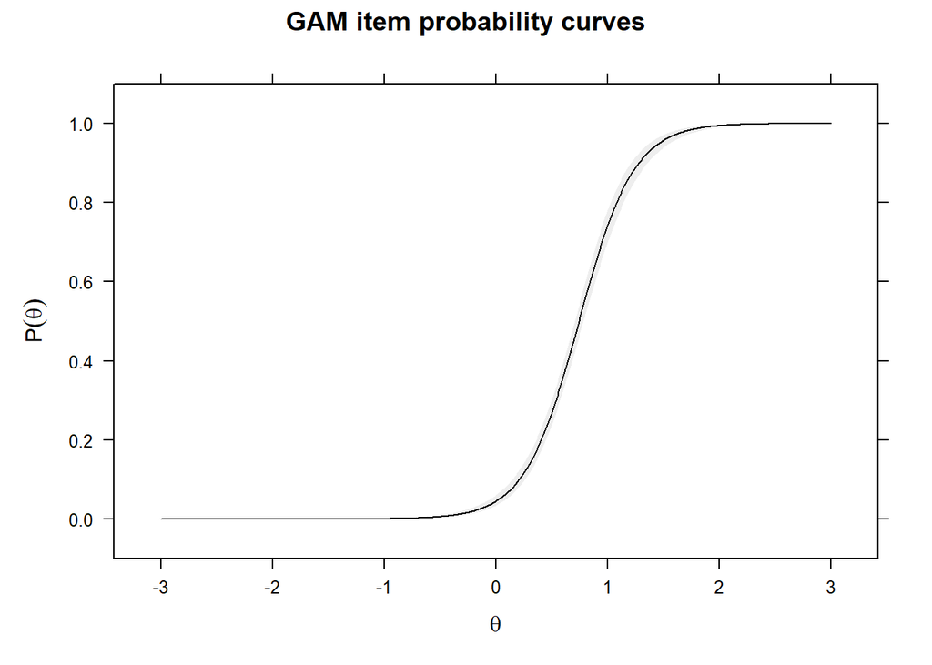

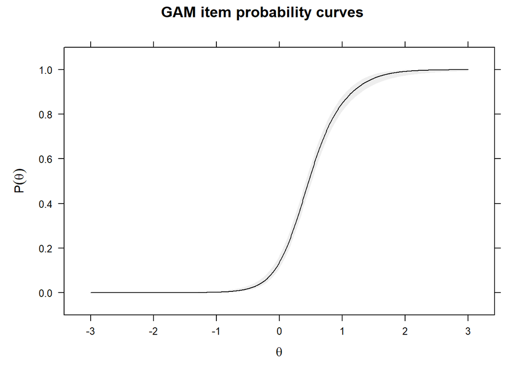

```r
plot(IG783); plot(IG792)
```

Look at the discrimination and difficulty parameters

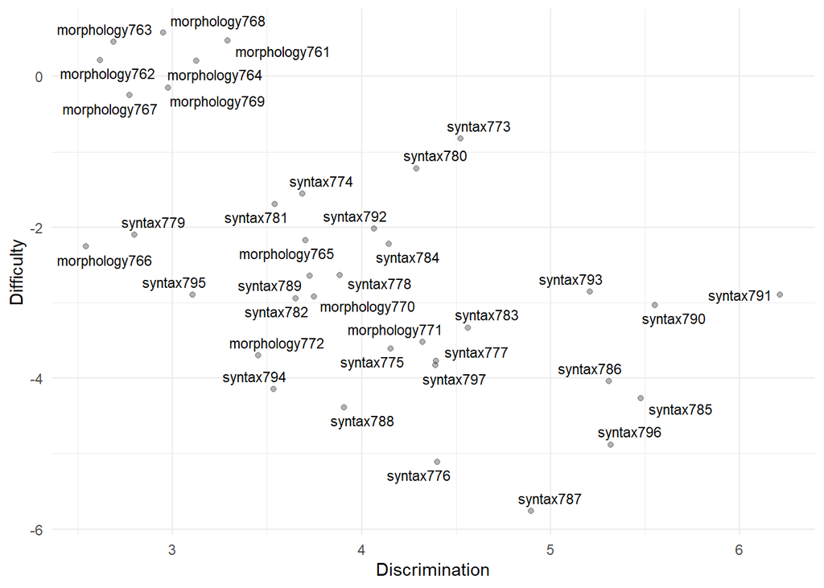

```r
coefs_2pl <- coef(m1, as.data.frame = TRUE) %>%
 t() %>%
  as_tibble() %>%
  dplyr::select(-c(149:150)) %>%
  pivot_longer(everything()) %>%
  tidyr::separate(, col=name, into=c("item", "parameter"), sep="([.])") %>%
  pivot_wider(id_cols=item, names_from=parameter, values_from=value) %>%
  dplyr::select(item, a1, d) %>%
  mutate(
   category =  gsub('[[:digit:]]+', '', item)
  )

ggplot(coefs_2pl,
       aes(x = a1, y = d)) +
  geom_point(alpha = .3) +
  ggrepel::geom_text_repel(data = coefs_2pl,
                  aes(label = item), size = 3) +
  xlab("Discrimination") +
  ylab("Difficulty") + theme_minimal()
```

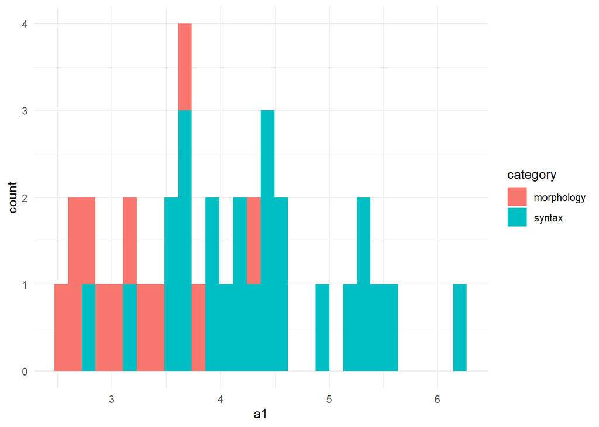

```r
ggplot(coefs_2pl, aes(x=a1, fill=category)) + geom_histogram() + theme_minimal()
```

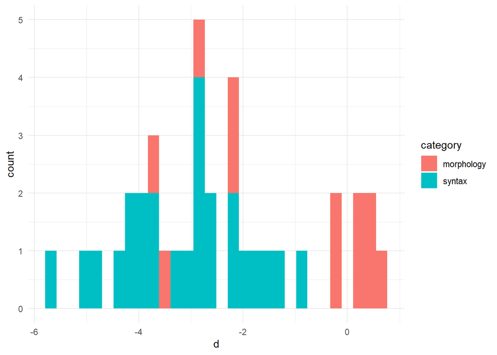

```r
ggplot(coefs_2pl, aes(x=d, fill=category)) + geom_histogram() + theme_minimal()
```

Next let’s look at the relationship between the true scores and the raw scores.

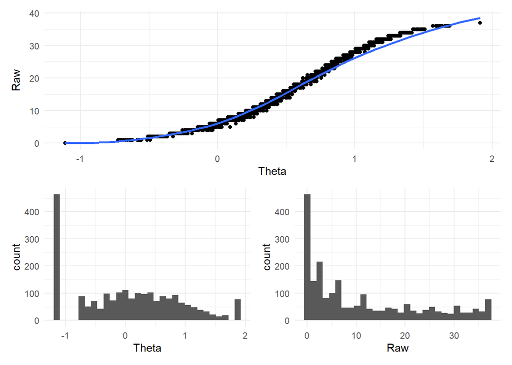

```r
true_raw <- Complex_short_grammatical %>%
  mutate(
    Raw = rowSums(.[,1:37]),
    Theta = fscores(m1, method="MAP")
  ) %>%
  ggplot(aes(x=Theta, y=Raw)) + geom_point() + stat_smooth(method="loess") + theme_minimal()

raw_score <- Complex_short_grammatical %>%
  mutate(
    Raw = rowSums(.[,1:37])
    ) %>%
   ggplot(aes(x=Raw)) + geom_histogram() + theme_minimal()

true_score <- Complex_short_grammatical %>%
  mutate(
    Theta = fscores(m1, method="MAP")
    ) %>%
   ggplot(aes(x=Theta)) + geom_histogram() + theme_minimal()

library(patchwork)

true_raw/(true_score + raw_score)
```

We still have a bunch of 0s.

## 1.2 Thinking Through the Assumptions of the 2PL model

It’s important to remember that these latent variables are only interpretable if the following conditions hold: 1. The assumption of unidimensionality is appropriate. 2. The assumed distributional form of the latent variable is correct. 3. Measurement invariance holds: the items behave the same way across different groups of participants.

### 1.2.1 Dimensionality

Exploratory 2 dimensional IRT.

```r
m2 <- mirt(Complex_short_grammatical, 2, itemtype="2PL", verbose=FALSE)
```

```r
M2(m2)
```

|  | M2 | df | p | RMSEA | RMSEA_5 | RMSEA_95 | SRMSR | TLI | CFI |
| --- | --- | --- | --- | --- | --- | --- | --- | --- | --- |
| stats | 1760.282 | 593 | 0 | 0.03002163 | 0.02840214 | 0.03163838 | 0.02640831 | 0.9966312 | 0.9970004 |

```r
anova(m1, m2)
```

```
##
## Model 1: mirt(data = Complex_short_grammatical, model = 1, itemtype = "2PL")
## Model 2: mirt(data = Complex_short_grammatical, model = 2, itemtype = "2PL",
##     verbose = FALSE)
```

| AIC | AICc | SABIC | HQ | BIC | logLik | X2 | df | p |
| --- | --- | --- | --- | --- | --- | --- | --- | --- |
| 49930.62 | 49935.88 | 50116.52 | 50084.51 | 50351.63 | -24891.31 | NaN | NaN | NaN |
| 49138.06 | 49149.84 | 49414.41 | 49366.83 | 49763.89 | -24459.03 | 864.5541 | 36 | 0 |

```r
summary(m2, "oblimin", suppress=.20)
```

```
##
## Rotation:  oblimin
##
## Rotated factor loadings:
##
##                   F1     F2    h2
## morphology761 -0.828 -0.268 0.827
## morphology762 -0.795     NA 0.718
## morphology763 -0.748 -0.418 0.834
## morphology764 -0.838     NA 0.779
## morphology765 -0.889     NA 0.817
## morphology766 -0.797     NA 0.696
## morphology767 -0.801 -0.222 0.747
## morphology768 -0.844     NA 0.751
## morphology769 -0.790 -0.353 0.838
## morphology770 -0.876     NA 0.846
## morphology771 -0.894     NA 0.892
## morphology772 -0.859     NA 0.825
## syntax773     -0.924     NA 0.871
## syntax774     -0.866 -0.200 0.845
## syntax775     -0.910     NA 0.843
## syntax776     -0.924     NA 0.858
## syntax777     -0.922     NA 0.858
## syntax778     -0.914     NA 0.829
## syntax779     -0.857     NA 0.719
## syntax780     -0.898     NA 0.873
## syntax781     -0.916     NA 0.819
## syntax782     -0.888     NA 0.811
## syntax783     -0.945     NA 0.875
## syntax784     -0.928     NA 0.849
## syntax785     -0.950     NA 0.902
## syntax786     -0.968     NA 0.913
## syntax787     -0.963     NA 0.904
## syntax788     -0.939  0.222 0.865
## syntax789     -0.925     NA 0.834
## syntax790     -0.967     NA 0.915
## syntax791     -0.965     NA 0.926
## syntax792     -0.936     NA 0.855
## syntax793     -0.962     NA 0.906
## syntax794     -0.916     NA 0.817
## syntax795     -0.894     NA 0.779
## syntax796     -0.968     NA 0.913
## syntax797     -0.949     NA 0.878
##
## Rotated SS loadings:  29.829 0.988
##
## Factor correlations:
##
##       F1    F2
## F1 1.000 0.159
## F2 0.159 1.000
```

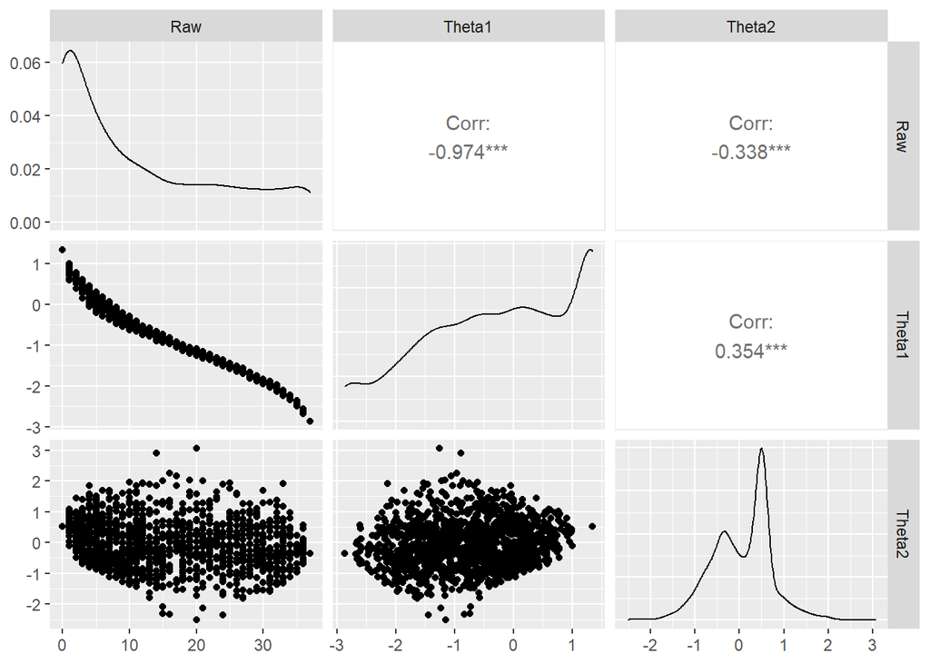

```r
Complex_short_grammatical %>%
  mutate(
    Raw = rowSums(.[,1:37]),
    Theta1 = fscores(m2, method="MAP")[,1],
    Theta2 = fscores(m2, method="MAP")[,2]
  ) %>%
  dplyr::select(Raw, Theta1, Theta2) %>%
  ggpairs()
```

Could this be due to morphological vs syntactic complexity items?

```r
model.1 <- mirt.model('
                      F1 = 1 - 12
                      F2 = 13 - 37
                      COV=F1*F2')

m3 <- mirt(Complex_short_grammatical, model.1, "2PL", verbose=FALSE)

M2(m3)
```

|  | M2 | df | p | RMSEA | RMSEA_5 | RMSEA_95 | SRMSR | TLI | CFI |
| --- | --- | --- | --- | --- | --- | --- | --- | --- | --- |
| stats | 2263.133 | 628 | 0 | 0.03452792 | 0.03299306 | 0.03605905 | 0.0247545 | 0.995544 | 0.9957982 |

```r
summary(m3)
```

```
##                  F1    F2    h2
## morphology761 0.906 0.000 0.821
## morphology762 0.846 0.000 0.716
## morphology763 0.859 0.000 0.738
## morphology764 0.881 0.000 0.776
## morphology765 0.900 0.000 0.811
## morphology766 0.832 0.000 0.692
## morphology767 0.855 0.000 0.731
## morphology768 0.864 0.000 0.747
## morphology769 0.882 0.000 0.778
## morphology770 0.922 0.000 0.851
## morphology771 0.951 0.000 0.904
## morphology772 0.907 0.000 0.823
## syntax773     0.000 0.925 0.856
## syntax774     0.000 0.888 0.788
## syntax775     0.000 0.908 0.825
## syntax776     0.000 0.919 0.845
## syntax777     0.000 0.919 0.845
## syntax778     0.000 0.901 0.812
## syntax779     0.000 0.835 0.698
## syntax780     0.000 0.915 0.838
## syntax781     0.000 0.891 0.794
## syntax782     0.000 0.890 0.792
## syntax783     0.000 0.926 0.858
## syntax784     0.000 0.912 0.833
## syntax785     0.000 0.944 0.892
## syntax786     0.000 0.943 0.889
## syntax787     0.000 0.938 0.880
## syntax788     0.000 0.908 0.824
## syntax789     0.000 0.897 0.805
## syntax790     0.000 0.951 0.904
## syntax791     0.000 0.959 0.919
## syntax792     0.000 0.913 0.834
## syntax793     0.000 0.943 0.889
## syntax794     0.000 0.889 0.790
## syntax795     0.000 0.861 0.741
## syntax796     0.000 0.943 0.890
## syntax797     0.000 0.922 0.850
##
## SS loadings:  9.388 20.889
## Proportion Var:  0.254 0.565
##
## Factor correlations:
##
##       F1    F2
## F1 1.000 0.951
## F2 0.951 1.000
```

```r
M2(m3)
```

|  | M2 | df | p | RMSEA | RMSEA_5 | RMSEA_95 | SRMSR | TLI | CFI |
| --- | --- | --- | --- | --- | --- | --- | --- | --- | --- |
| stats | 2263.133 | 628 | 0 | 0.03452792 | 0.03299306 | 0.03605905 | 0.0247545 | 0.995544 | 0.9957982 |

```r
anova(m3, m2)
```

```
##
## Model 1: mirt(data = Complex_short_grammatical, model = model.1, itemtype = "2PL",
##     verbose = FALSE)
## Model 2: mirt(data = Complex_short_grammatical, model = 2, itemtype = "2PL",
##     verbose = FALSE)
```

| AIC | AICc | SABIC | HQ | BIC | logLik | X2 | df | p |
| --- | --- | --- | --- | --- | --- | --- | --- | --- |
| 49531.30 | 49536.71 | 49719.72 | 49687.28 | 49958.01 | -24690.65 | NaN | NaN | NaN |
| 49138.06 | 49149.84 | 49414.41 | 49366.83 | 49763.89 | -24459.03 | 463.2436 | 35 | 0 |

```r
anova(m3, m1)
```

```
##
## Model 1: mirt(data = Complex_short_grammatical, model = 1, itemtype = "2PL")
## Model 2: mirt(data = Complex_short_grammatical, model = model.1, itemtype = "2PL",
##     verbose = FALSE)
```

| AIC | AICc | SABIC | HQ | BIC | logLik | X2 | df | p |
| --- | --- | --- | --- | --- | --- | --- | --- | --- |
| 49930.62 | 49935.88 | 50116.52 | 50084.51 | 50351.63 | -24891.31 | NaN | NaN | NaN |
| 49531.30 | 49536.71 | 49719.72 | 49687.28 | 49958.01 | -24690.65 | 401.3105 | 1 | 0 |

### 1.2.2 Semi-parametric latent variables.

```r
m1_nonpar <- mirt(Complex_short_grammatical, 1, itemtype="2PL", dentype = "EH", verbose=FALSE)

M2(m1_nonpar)
```

|  | M2 | df | p | RMSEA | RMSEA_5 | RMSEA_95 | SRMSR | TLI | CFI |
| --- | --- | --- | --- | --- | --- | --- | --- | --- | --- |
| stats | 2975.655 | 509 | 0 | 0.04710522 | 0.04546375 | 0.0487399 | 0.2252689 | 0.9917063 | 0.9936614 |

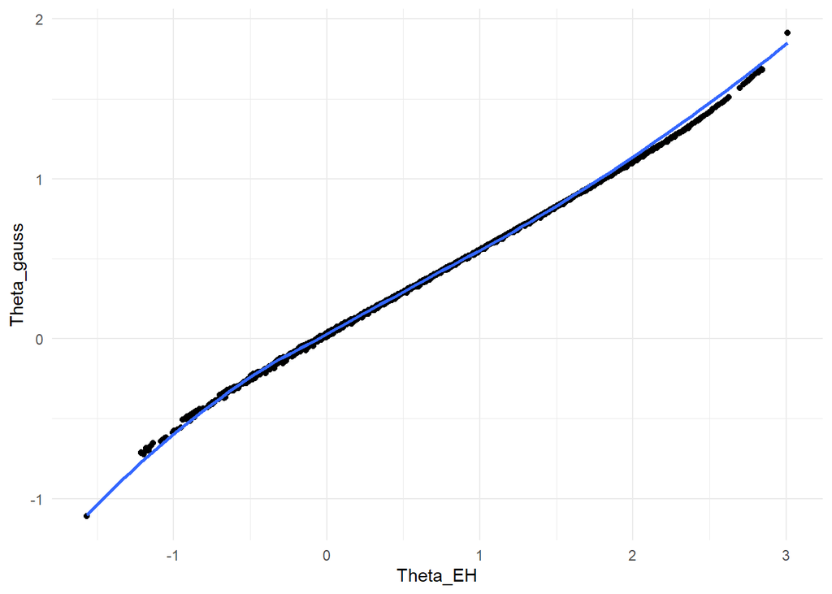

```r
Complex_short_grammatical %>%
  mutate(
    Theta_EH = fscores(m1_nonpar, method="MAP"),
    Theta_gauss = fscores(m1, method="MAP")
  ) %>%
  ggplot(aes(x=Theta_EH, y=Theta_gauss)) + geom_point() + stat_smooth(method="loess") + theme_minimal()
```

```r
m1_nonpar <- mirt(Complex_short_grammatical, 1, itemtype="2PL", dentype = "EHW", verbose=FALSE)
```

```
## EM cycles terminated after 2000 iterations.
```

```r
M2(m1_nonpar)
```

|  | M2 | df | p | RMSEA | RMSEA_5 | RMSEA_95 | SRMSR | TLI | CFI |
| --- | --- | --- | --- | --- | --- | --- | --- | --- | --- |
| stats | 4285.203 | 511 | 0 | 0.0581535 | 0.05653837 | 0.05975516 | 0.1696374 | 0.9873596 | 0.9903014 |

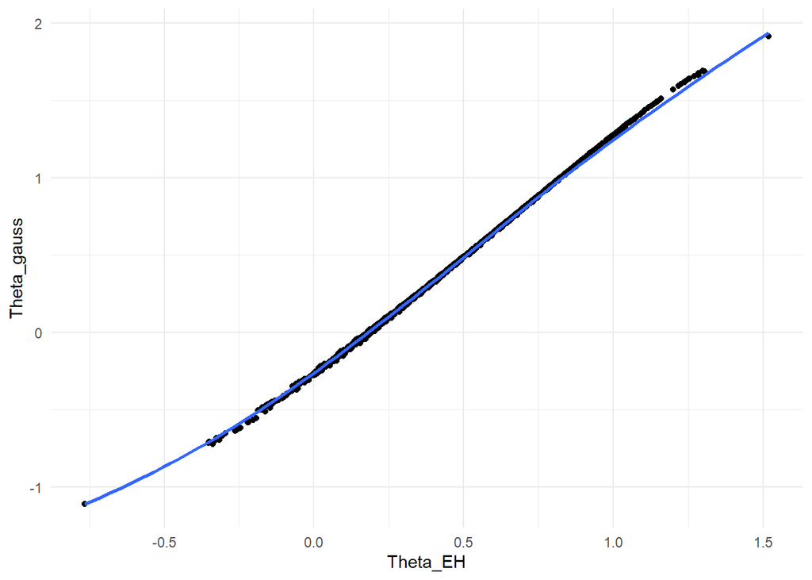

```r
Complex_short_grammatical %>%
  mutate(
    Theta_EH = fscores(m1_nonpar, method="MAP"),
    Theta_gauss = fscores(m1, method="MAP")
  ) %>%
  ggplot(aes(x=Theta_EH, y=Theta_gauss)) + geom_point() + stat_smooth(method="loess") + theme_minimal()
```